# tree_data_analysis

Liyenne

2023-09-12

# Data

**individual tree data**

```
## # A tibble: 10 × 8
##    transect country section distance height class diameter n_stems
##    <chr>    <chr>   <chr>      <dbl>  <dbl> <chr>    <dbl>   <dbl>
##  1 F2       Finland forest     -33.3   1000 tree       185       1
##  2 F3       Finland forest     -39      910 tree       201       2
##  3 F2       Finland forest     -39.6    910 tree       162       1
##  4 F2       Finland forest     -32.5    910 tree       101       1
##  5 F2       Finland forest     -34.5    860 tree       178       1
##  6 F2       Finland forest     -42.4    850 tree       110       1
##  7 F2       Finland forest     -33.1    850 tree        79       2
##  8 F3       Finland forest     -43.3    830 tree       110       1
##  9 F3       Finland forest     -42.9    810 tree       114       3
## 10 F7       Finland forest      -6.3    810 tree        63       1
```

**transect meta/environmental data**

```
## # A tibble: 10 × 8
##    transect country habitat  total_dung elevation slope aspect   twi
##    <chr>    <chr>   <chr>         <dbl>     <dbl> <dbl>  <dbl> <dbl>
##  1 F1       Finland forest           22      604. 16.8   179.   6.70
##  2 F1       Finland treeline         35      617. 14.4   192.   7.39
##  3 F1       Finland tundra           33      627. 11.5   199.   7.44
##  4 F10      Finland forest           16      548.  5.35   90.3  5.77
##  5 F10      Finland treeline         69      551.  9.92  141.   5.48
##  6 F10      Finland tundra           76      561. 15.3    87.4  4.28
##  7 F2       Finland forest           95      650. 24.4   219.   5.99
##  8 F2       Finland treeline         42      669. 19.2   226.   6.39
##  9 F2       Finland tundra           50      689. 25.7   215.   5.30
## 10 F3       Finland forest           23      645. 26.4   213.   5.73
```

**tree data summarized per transect**

```
## # A tibble: 10 × 8
##    transect country section  class      n mean_height mean_diameter mean_n_stems
##    <chr>    <chr>   <chr>    <chr>  <dbl>       <dbl>         <dbl>        <dbl>
##  1 F1       Finland forest   dead       5         NA           NA          NA
##  2 F1       Finland forest   sapli…     3        178.          28.3         1
##  3 F1       Finland forest   seedl…     0         NA           NA          NA
##  4 F1       Finland forest   tree      21        376.          52.2         2.05
##  5 F1       Finland treeline dead       1         NA           NA          NA
##  6 F1       Finland treeline sapli…     1        160           11           1
##  7 F1       Finland treeline seedl…     2         12            2           1
##  8 F1       Finland treeline tree       0         NA           NA          NA
##  9 F1       Finland tundra   dead       0         NA           NA          NA
## 10 F1       Finland tundra   sapli…     0         NA           NA          NA
```

# Analysis

**numbers of trees**

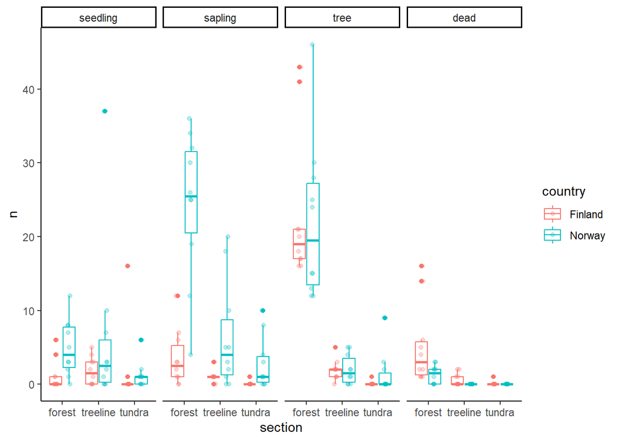

The models (GLMMs) below model numbers of individuals against “Country” and “Habitat” (called “section” in the data set). To reduce the complexity of the model and since I am not interested in relationships between tree classes, I ran this model over subsets containing data for each tree class separately (i.e., seedling, sapling, adult tree, or dead tree). This data set includes 0 when no individuals of said classes were found in a given section of the transects.

**Seedlings**

```r
# seedlings
d <- tree_transect_data_full %>%
  filter(class == "seedling")

fit <- glmer(n ~ country * section + (country | transect) + (1 | section), family = poisson, data = d)
```

```
## boundary (singular) fit: see help('isSingular')
```

```r
summary(fit)
```

```
## Generalized linear mixed model fit by maximum likelihood (Laplace
##   Approximation) [glmerMod]
##  Family: poisson  ( log )
## Formula: n ~ country * section + (country | transect) + (1 | section)
##    Data: d
##
##      AIC      BIC   logLik deviance df.resid
##      318      339     -149      298       50
##
## Scaled residuals:
##     Min      1Q  Median      3Q     Max
## -3.1253 -0.8692 -0.4333  0.5607  3.9598
##
## Random effects:
##  Groups   Name          Variance Std.Dev. Corr
##  transect (Intercept)   2.0581   1.4346
##           countryNorway 0.6652   0.8156   -0.93
##  section  (Intercept)   0.0000   0.0000
## Number of obs: 60, groups:  transect, 20; section, 3
##
## Fixed effects:
##                               Estimate Std. Error z value Pr(>|z|)
## (Intercept)                    -0.7057     0.6209  -1.137 0.255673
## countryNorway                   2.0041     0.6828   2.935 0.003335 **
## sectiontreeline                 0.4055     0.3727   1.088 0.276595
## sectiontundra                   0.3483     0.3770   0.924 0.355582
## countryNorway:sectiontreeline  -0.1542     0.4185  -0.368 0.712633
## countryNorway:sectiontundra    -1.7552     0.4959  -3.540 0.000401 ***
## ---
## Signif. codes:  0 '***' 0.001 '**' 0.01 '*' 0.05 '.' 0.1 ' ' 1
##
## Correlation of Fixed Effects:
##                  (Intr) cntryN sctntr sctntn cntryNrwy:sctntr
## countryNrwy      -0.909
## sectiontrln      -0.360  0.327
## sectiontndr      -0.356  0.324  0.593
## cntryNrwy:sctntr  0.321 -0.363 -0.890 -0.528
## cntryNrwy:sctntn  0.271 -0.306 -0.451 -0.760  0.500
## optimizer (Nelder_Mead) convergence code: 0 (OK)
## boundary (singular) fit: see help('isSingular')
```

```r
lsmeans(fit, pairwise ~ country*section, lmer.df = "Satterthwaite", adjust = "tukey")$contrasts
```

```
##  contrast                           estimate    SE  df z.ratio p.value
##  Finland forest - Norway forest      -2.0041 0.683 Inf  -2.935  0.0391
##  Finland forest - Finland treeline   -0.4055 0.373 Inf  -1.088  0.8864
##  Finland forest - Norway treeline    -2.2554 0.679 Inf  -3.319  0.0116
##  Finland forest - Finland tundra     -0.3483 0.377 Inf  -0.924  0.9405
##  Finland forest - Norway tundra      -0.5972 0.727 Inf  -0.821  0.9638
##  Norway forest - Finland treeline     1.5986 0.662 Inf   2.414  0.1512
##  Norway forest - Norway treeline     -0.2513 0.190 Inf  -1.319  0.7744
##  Norway forest - Finland tundra       1.6558 0.665 Inf   2.491  0.1265
##  Norway forest - Norway tundra        1.4069 0.322 Inf   4.368  0.0002
##  Finland treeline - Norway treeline  -1.8499 0.659 Inf  -2.808  0.0561
##  Finland treeline - Finland tundra    0.0572 0.338 Inf   0.169  1.0000
##  Finland treeline - Norway tundra    -0.1917 0.708 Inf  -0.271  0.9998
##  Norway treeline - Finland tundra     1.9071 0.661 Inf   2.884  0.0453
##  Norway treeline - Norway tundra      1.6582 0.315 Inf   5.265  <.0001
##  Finland tundra - Norway tundra      -0.2489 0.710 Inf  -0.350  0.9993
##
## Results are given on the log (not the response) scale.
## P value adjustment: tukey method for comparing a family of 6 estimates
```

• Higher numbers of seedlings were only found in the forest in Norway in comparison to the forest in Finland (p = 0.0391). Slightly higher numbers of seedlings were found in the Norwegian treeline compared to the Finnish treeline, although this finding lacks statistical support (p = 0.0561).

**Saplings**

```r
# saplings
d <- tree_transect_data_full %>%
  filter(class == "sapling")

fit <- glmer(n ~ country * section + (country | transect) + (1 | section), family = poisson, data = d)
```

```
## boundary (singular) fit: see help('isSingular')
```

```r
summary(fit)
```

```
## Generalized linear mixed model fit by maximum likelihood (Laplace
##   Approximation) [glmerMod]
##  Family: poisson  ( log )
## Formula: n ~ country * section + (country | transect) + (1 | section)
##    Data: d
##
##      AIC      BIC   logLik deviance df.resid
##    319.4    340.3   -149.7    299.4       50
##
## Scaled residuals:
##     Min      1Q  Median      3Q     Max
## -2.6007 -0.7979 -0.2815  0.5766  3.7793
##
## Random effects:
##  Groups   Name          Variance Std.Dev. Corr
##  transect (Intercept)   0.3636   0.603
##           countryNorway 1.3111   1.145    -1.00
##  section  (Intercept)   0.0000   0.000
## Number of obs: 60, groups:  transect, 20; section, 3
##
## Fixed effects:
##                               Estimate Std. Error z value Pr(>|z|)
## (Intercept)                    1.07291    0.27288   3.932 8.43e-05 ***
## countryNorway                  1.99642    0.33054   6.040 1.54e-09 ***
## sectiontreeline               -1.25276    0.35175  -3.562 0.000369 ***
## sectiontundra                 -3.55535    0.99490  -3.574 0.000352 ***
## countryNorway:sectiontreeline -0.08142    0.37847  -0.215 0.829672
## countryNorway:sectiontundra    1.39449    1.01448   1.375 0.169261
## ---
## Signif. codes:  0 '***' 0.001 '**' 0.01 '*' 0.05 '.' 0.1 ' ' 1
##
## Correlation of Fixed Effects:
##                  (Intr) cntryN sctntr sctntn cntryNrwy:sctntr
## countryNrwy      -0.826
## sectiontrln      -0.286  0.236
## sectiontndr      -0.101  0.084  0.079
## cntryNrwy:sctntr  0.266 -0.252 -0.929 -0.073
## cntryNrwy:sctntn  0.099 -0.094 -0.077 -0.981  0.082
## optimizer (Nelder_Mead) convergence code: 0 (OK)
## boundary (singular) fit: see help('isSingular')
```

```r
lsmeans(fit, pairwise ~ country*section, lmer.df = "Satterthwaite", adjust = "tukey")$contrasts
```

```
##  contrast                           estimate    SE  df z.ratio p.value
##  Finland forest - Norway forest       -1.996 0.331 Inf  -6.040  <.0001
##  Finland forest - Finland treeline     1.253 0.352 Inf   3.562  0.0050
##  Finland forest - Norway treeline     -0.662 0.347 Inf  -1.907  0.3979
##  Finland forest - Finland tundra       3.555 0.995 Inf   3.574  0.0047
##  Finland forest - Norway tundra        0.164 0.375 Inf   0.439  0.9980
##  Norway forest - Finland treeline      3.249 0.422 Inf   7.701  <.0001
##  Norway forest - Norway treeline       1.334 0.140 Inf   9.552  <.0001
##  Norway forest - Finland tundra        5.552 1.022 Inf   5.433  <.0001
##  Norway forest - Norway tundra         2.161 0.198 Inf  10.891  <.0001
##  Finland treeline - Norway treeline   -1.915 0.435 Inf  -4.401  0.0002
##  Finland treeline - Finland tundra     2.303 1.029 Inf   2.238  0.2203
##  Finland treeline - Norway tundra     -1.088 0.457 Inf  -2.379  0.1634
##  Norway treeline - Finland tundra      4.218 1.027 Inf   4.105  0.0006
##  Norway treeline - Norway tundra       0.827 0.225 Inf   3.670  0.0033
##  Finland tundra - Norway tundra       -3.391 1.037 Inf  -3.270  0.0137
##
## Results are given on the log (not the response) scale.
## P value adjustment: tukey method for comparing a family of 6 estimates
```

• Sapling numbers were consistently higher in Norway in all habitats (forest, p < 0.0001; treeline, p = 0.0002; tundra, p = 0.0137) when compared to Finland, suggesting that intense grazing regimes limit recruitment in Finland.

**Adult trees**

```r
# adult trees
d <- tree_transect_data_full %>%
  filter(class == "tree")

fit <- glmer(n ~ country * section + (country | transect) + (1 | section), family = poisson, data = d)
```

```
## boundary (singular) fit: see help('isSingular')
```

```r
summary(fit)
```

```
## Generalized linear mixed model fit by maximum likelihood (Laplace
##   Approximation) [glmerMod]
##  Family: poisson  ( log )
## Formula: n ~ country * section + (country | transect) + (1 | section)
##    Data: d
##
##      AIC      BIC   logLik deviance df.resid
##    293.1    314.1   -136.6    273.1       50
##
## Scaled residuals:
##     Min      1Q  Median      3Q     Max
## -2.1422 -0.7044 -0.2863  0.3216  6.4109
##
## Random effects:
##  Groups   Name          Variance Std.Dev. Corr
##  transect (Intercept)   0.09976  0.3158
##           countryNorway 0.02806  0.1675   -0.08
##  section  (Intercept)   0.00000  0.0000
## Number of obs: 60, groups:  transect, 20; section, 3
##
## Fixed effects:
##                               Estimate Std. Error z value Pr(>|z|)
## (Intercept)                    3.08206    0.12136  25.396  < 2e-16 ***
## countryNorway                 -0.05111    0.17797  -0.287  0.77397
## sectiontreeline               -2.49364    0.23753 -10.498  < 2e-16 ***
## sectiontundra                 -5.43808    0.99724  -5.453 4.95e-08 ***
## countryNorway:sectiontreeline  0.09574    0.33224   0.288  0.77321
## countryNorway:sectiontundra    2.68351    1.03424   2.595  0.00947 **
## ---
## Signif. codes:  0 '***' 0.001 '**' 0.01 '*' 0.05 '.' 0.1 ' ' 1
##
## Correlation of Fixed Effects:
##                  (Intr) cntryN sctntr sctntn cntryNrwy:sctntr
## countryNrwy      -0.682
## sectiontrln      -0.149  0.102
## sectiontndr      -0.036  0.024  0.018
## cntryNrwy:sctntr  0.107 -0.149 -0.715 -0.013
## cntryNrwy:sctntn  0.034 -0.048 -0.018 -0.964  0.026
## optimizer (Nelder_Mead) convergence code: 0 (OK)
## boundary (singular) fit: see help('isSingular')
```

**Dead trees**

```r
# dead
d <- tree_transect_data_full %>%
  filter(class == "dead")

fit <- glmer(n ~ country * section + (country | transect) + (1 | section), family = poisson, data = d)
```

```
## boundary (singular) fit: see help('isSingular')
```

```r
summary(fit)
```

```
## Generalized linear mixed model fit by maximum likelihood (Laplace
##   Approximation) [glmerMod]
##  Family: poisson  ( log )
## Formula: n ~ country * section + (country | transect) + (1 | section)
##    Data: d
##
##      AIC      BIC   logLik deviance df.resid
##    135.0    155.9    -57.5    115.0       50
##
## Scaled residuals:
##      Min       1Q   Median       3Q      Max
## -1.23631 -0.45952 -0.00004 -0.00003  2.45282
##
## Random effects:
##  Groups   Name          Variance Std.Dev. Corr
##  transect (Intercept)   0.6286   0.7929
##           countryNorway 0.7432   0.8621   -0.94
##  section  (Intercept)   0.0000   0.0000
## Number of obs: 60, groups:  transect, 20; section, 3
##
## Fixed effects:
##                                Estimate Std. Error z value Pr(>|z|)
## (Intercept)                      1.3453     0.3120   4.312 1.62e-05 ***
## countryNorway                   -1.1281     0.4788  -2.356   0.0185 *
## sectiontreeline                 -2.1595     0.4312  -5.009 5.48e-07 ***
## sectiontundra                   -3.9512     1.0096  -3.914 9.09e-05 ***
## countryNorway:sectiontreeline  -18.2527  1026.0768  -0.018   0.9858
## countryNorway:sectiontundra    -17.0954   726.9145  -0.024   0.9812
## ---
## Signif. codes:  0 '***' 0.001 '**' 0.01 '*' 0.05 '.' 0.1 ' ' 1
##
## Correlation of Fixed Effects:
##                  (Intr) cntryN sctntr sctntn cntryNrwy:sctntr
## countryNrwy      -0.652
## sectiontrln      -0.143  0.093
## sectiontndr      -0.061  0.040  0.044
## cntryNrwy:sctntr  0.000  0.000  0.000  0.000
## cntryNrwy:sctntn  0.000  0.000  0.000  0.000 -0.155
## optimizer (Nelder_Mead) convergence code: 0 (OK)
## boundary (singular) fit: see help('isSingular')
```

**Relationship between trees and dung counts**

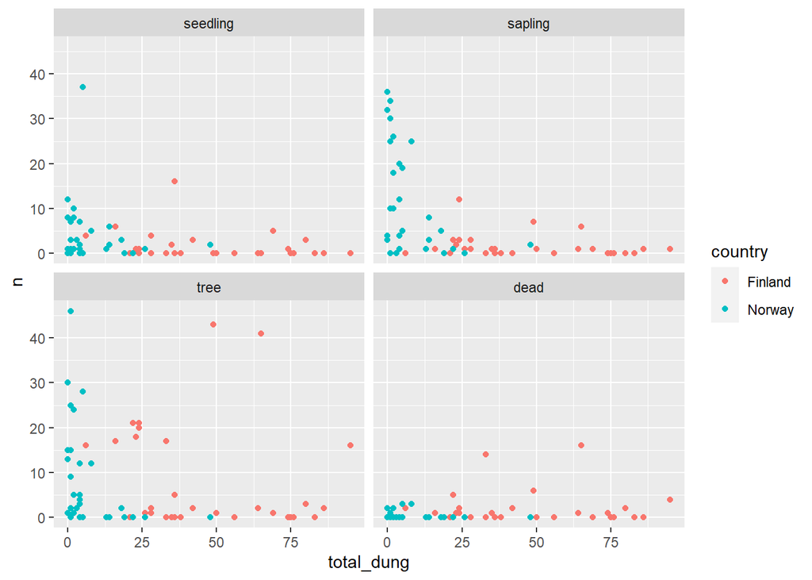

```r
fit <- tree_transect_data_full %>%
  rename(habitat = section) %>%
  inner_join(transect_data) %>%
  filter(class == "seedling") %>%
  glmer(n ~ total_dung + (country | transect) + (1  | habitat), family = poisson, data = .)
summary(fit)
```

```
## Generalized linear mixed model fit by maximum likelihood (Laplace
##   Approximation) [glmerMod]
##  Family: poisson  ( log )
## Formula: n ~ total_dung + (country | transect) + (1 | habitat)
##    Data: .
##
##      AIC      BIC   logLik deviance df.resid
##    334.7    347.2   -161.3    322.7       54
##
## Scaled residuals:
##     Min      1Q  Median      3Q     Max
## -2.7627 -0.9312 -0.5029  0.1876  6.2606
##
## Random effects:
##  Groups   Name          Variance Std.Dev. Corr
##  transect (Intercept)   1.9923   1.4115
##           countryNorway 0.7752   0.8805   -0.88
##  habitat  (Intercept)   0.1417   0.3765
## Number of obs: 60, groups:  transect, 20; habitat, 3
##
## Fixed effects:
##              Estimate Std. Error z value Pr(>|z|)
## (Intercept)  0.968895   0.358557   2.702  0.00689 **
## total_dung  -0.016561   0.006782  -2.442  0.01461 *
## ---
## Signif. codes:  0 '***' 0.001 '**' 0.01 '*' 0.05 '.' 0.1 ' ' 1
##
## Correlation of Fixed Effects:
##            (Intr)
## total_dung -0.286
## optimizer (Nelder_Mead) convergence code: 0 (OK)
## unable to evaluate scaled gradient
## Model failed to converge: degenerate  Hessian with 1 negative eigenvalues
```

```r
anova(fit)
```

```
## Analysis of Variance Table
##            npar Sum Sq Mean Sq F value
## total_dung    1 6.0382  6.0382  6.0382
```

```r
fit <- tree_transect_data_full %>%
  rename(habitat = section) %>%
  inner_join(transect_data) %>%
  filter(class == "sapling") %>%
  glmer(n ~ total_dung + (country | transect) + (1  | habitat), family = poisson, data = .)
summary(fit)
```

```
## Generalized linear mixed model fit by maximum likelihood (Laplace
##   Approximation) [glmerMod]
##  Family: poisson  ( log )
## Formula: n ~ total_dung + (country | transect) + (1 | habitat)
##    Data: .
##
##      AIC      BIC   logLik deviance df.resid
##    332.0    344.5   -160.0    320.0       54
##
## Scaled residuals:
##     Min      1Q  Median      3Q     Max
## -2.7558 -0.7966 -0.2041  0.3629  2.9941
##
## Random effects:
##  Groups   Name          Variance Std.Dev. Corr
##  transect (Intercept)   1.8238   1.3505
##           countryNorway 1.0843   1.0413   -0.90
##  habitat  (Intercept)   0.6946   0.8335
## Number of obs: 60, groups:  transect, 20; habitat, 3
##
## Fixed effects:
##              Estimate Std. Error z value Pr(>|z|)
## (Intercept)  1.888113   0.548101   3.445 0.000571 ***
## total_dung  -0.031882   0.007857  -4.058 4.95e-05 ***
## ---
## Signif. codes:  0 '***' 0.001 '**' 0.01 '*' 0.05 '.' 0.1 ' ' 1
##
## Correlation of Fixed Effects:
##            (Intr)
## total_dung -0.148
## optimizer (Nelder_Mead) convergence code: 0 (OK)
## Model is nearly unidentifiable: large eigenvalue ratio
##  - Rescale variables?
```

```r
anova(fit)
```

```
## Analysis of Variance Table
##            npar Sum Sq Mean Sq F value
## total_dung    1 16.338  16.338  16.338
```

• This is corroborated by the significant negative relationship between dung counts and numbers of seedlings (GLMM, F1 = 6.03, p = 0.0146) and saplings (GLMM, F1 = 16.34, p < 0.0001) found in the transects.

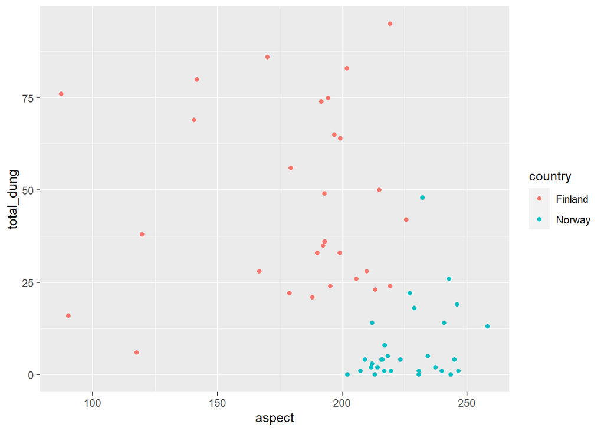

```r
tree_transect_data_full %>%
  rename(habitat = section) %>%
  inner_join(transect_data) %>%
  ggplot(aes(x = aspect, y = total_dung, color = country)) +
  geom_point()
```

```r
fit <- transect_data %>%
  lmer(aspect ~ country + (country | transect) + (1  | habitat), data = .)
```

```
## boundary (singular) fit: see help('isSingular')
```

```r
summary(fit)
```

```
## Linear mixed model fit by REML. t-tests use Satterthwaite's method [
## lmerModLmerTest]
## Formula: aspect ~ country + (country | transect) + (1 | habitat)
##    Data: .
##
## REML criterion at convergence: 524.9
##
## Scaled residuals:
##      Min       1Q   Median       3Q      Max
## -2.45493 -0.53245  0.03155  0.51315  2.44191
##
## Random effects:
##  Groups   Name          Variance Std.Dev. Corr
##  transect (Intercept)   1024.4   32.01
##           countryNorway 1591.0   39.89    -1.00
##  habitat  (Intercept)      0.0    0.00
##  Residual                278.1   16.68
## Number of obs: 60, groups:  transect, 20; habitat, 3
##
## Fixed effects:
##               Estimate Std. Error     df t value Pr(>|t|)
## (Intercept)     180.97      10.57   9.00  17.122 3.56e-08 ***
## countryNorway    45.49      11.28  11.46   4.033  0.00182 **
## ---
## Signif. codes:  0 '***' 0.001 '**' 0.01 '*' 0.05 '.' 0.1 ' ' 1
##
## Correlation of Fixed Effects:
##             (Intr)
## countryNrwy -0.937
## optimizer (nloptwrap) convergence code: 0 (OK)
## boundary (singular) fit: see help('isSingular')
```

```r
anova(fit)
```

```
## Type III Analysis of Variance Table with Satterthwaite's method
##         Sum Sq Mean Sq NumDF  DenDF F value   Pr(>F)
## country 4523.2  4523.2     1 11.458  16.264 0.001819 **
## ---
## Signif. codes:  0 '***' 0.001 '**' 0.01 '*' 0.05 '.' 0.1 ' ' 1
```

## Adult tree morphology

**numbers of stems**

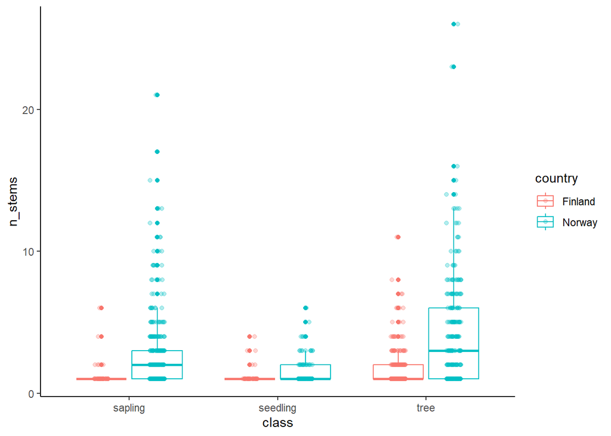

```r
tree_data %>%
  na.omit() %>%
  ggplot(aes(class, n_stems, color = country)) +
  geom_boxplot() +
  geom_jitter(aes(), alpha = 0.3, position = position_jitterdodge(jitter.width = 0.1, dodge.width = 0.75)) +
  theme_classic()
```

```r
fit <- tree_transect_data %>%
  rename(habitat = section) %>%
  full_join(transect_data) %>%
  filter(class != "dead") %>%
  lmer(mean_n_stems ~ country * class + (country | transect) + (1 | habitat), data = .)
```

```
## boundary (singular) fit: see help('isSingular')
```

```r
summary(fit)
```

```
## Linear mixed model fit by REML. t-tests use Satterthwaite's method [
## lmerModLmerTest]
## Formula: mean_n_stems ~ country * class + (country | transect) + (1 |
##     habitat)
##    Data: .
##
## REML criterion at convergence: 411.6
##
## Scaled residuals:
##     Min      1Q  Median      3Q     Max
## -2.5643 -0.4433 -0.1657  0.2547  5.5139
##
## Random effects:
##  Groups   Name          Variance Std.Dev. Corr
##  transect (Intercept)   0.00000  0.0000
##           countryNorway 0.07688  0.2773    NaN
##  habitat  (Intercept)   0.00000  0.0000
##  Residual               2.06637  1.4375
## Number of obs: 116, groups:  transect, 20; habitat, 3
##
## Fixed effects:
##                              Estimate Std. Error        df t value Pr(>|t|)
## (Intercept)                   1.63725    0.34864 101.42282   4.696 8.34e-06 ***
## countryNorway                 0.91991    0.46083  94.61927   1.996  0.04878 *
## classseedling                -0.38170    0.54199 101.42282  -0.704  0.48288
## classtree                     0.09953    0.47420 101.42282   0.210  0.83418
## countryNorway:classseedling  -0.62178    0.68671 103.45777  -0.905  0.36733
## countryNorway:classtree       2.16998    0.64205 103.94492   3.380  0.00102 **
## ---
## Signif. codes:  0 '***' 0.001 '**' 0.01 '*' 0.05 '.' 0.1 ' ' 1
##
## Correlation of Fixed Effects:
##                 (Intr) cntryN clsssd clsstr cntryNrwy:clsss
## countryNrwy     -0.757
## classsedlng     -0.643  0.487
## classtree       -0.735  0.556  0.473
## cntryNrwy:clsss  0.508 -0.646 -0.789 -0.373
## cntryNrwy:clsst  0.543 -0.692 -0.349 -0.739  0.464
## optimizer (nloptwrap) convergence code: 0 (OK)
## boundary (singular) fit: see help('isSingular')
```

```r
anova(fit)
```

```
## Type III Analysis of Variance Table with Satterthwaite's method
##               Sum Sq Mean Sq NumDF   DenDF F value    Pr(>F)
## country       51.134  51.134     1  34.853 24.7460 1.750e-05 ***
## class         64.791  32.395     2 103.796 15.6774 1.123e-06 ***
## country:class 39.737  19.869     2 103.796  9.6152 0.0001476 ***
## ---
## Signif. codes:  0 '***' 0.001 '**' 0.01 '*' 0.05 '.' 0.1 ' ' 1
```

```r
lsmeans(fit, pairwise ~ country * class, lmer.df = "Satterthwaite", adjust = "tukey")$contrasts
```

```
##  contrast                           estimate    SE    df t.ratio p.value
##  Finland sapling - Norway sapling    -0.9199 0.461  94.6  -1.996  0.3523
##  Finland sapling - Finland seedling   0.3817 0.542 101.4   0.704  0.9810
##  Finland sapling - Norway seedling    0.0836 0.474  93.6   0.176  1.0000
##  Finland sapling - Finland tree      -0.0995 0.474 101.4  -0.210  0.9999
##  Finland sapling - Norway tree       -3.1894 0.483  96.8  -6.600  <.0001
##  Norway sapling - Finland seedling    1.3016 0.513 102.5   2.538  0.1228
##  Norway sapling - Norway seedling     1.0035 0.422 106.3   2.380  0.1728
##  Norway sapling - Finland tree        0.8204 0.441  90.2   1.862  0.4322
##  Norway sapling - Norway tree        -2.2695 0.433 106.5  -5.243  <.0001
##  Finland seedling - Norway seedling  -0.2981 0.524 101.6  -0.568  0.9928
##  Finland seedling - Finland tree     -0.4812 0.525 101.4  -0.917  0.9414
##  Finland seedling - Norway tree      -3.5711 0.533 103.4  -6.699  <.0001
##  Norway seedling - Finland tree      -0.1831 0.454  89.3  -0.403  0.9986
##  Norway seedling - Norway tree       -3.2730 0.446 106.8  -7.340  <.0001
##  Finland tree - Norway tree          -3.0899 0.464  93.1  -6.660  <.0001
##
## Degrees-of-freedom method: satterthwaite
## P value adjustment: tukey method for comparing a family of 6 estimates
```

**height and diameter**

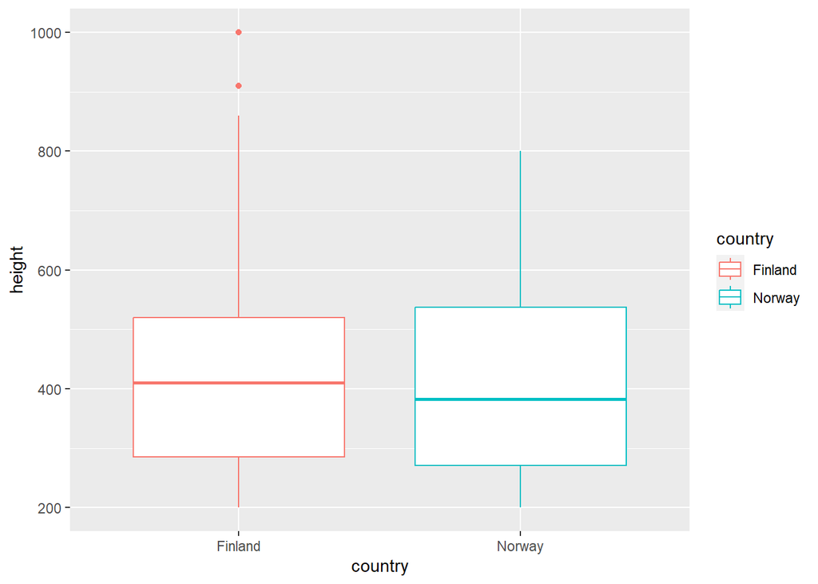

```r
tree_data %>%
  filter(class == 'tree') %>%
  ggplot(aes(country, height, color = country)) +
  geom_boxplot()
```

**height to diameter ratio** adult trees

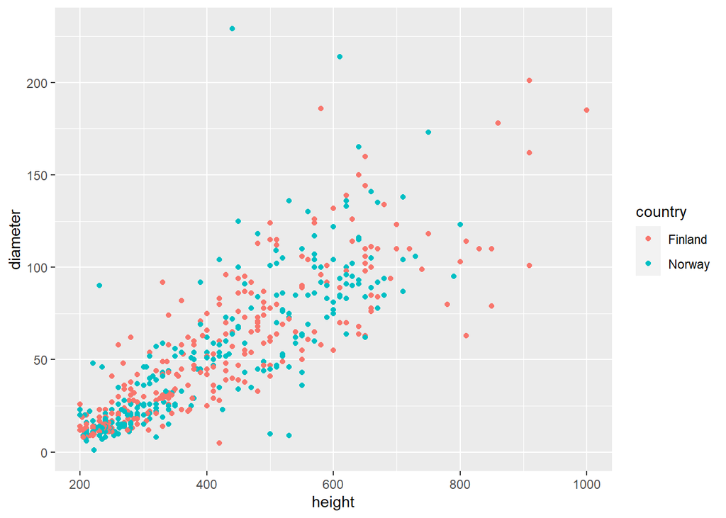

```r
tree_data %>%
  filter(class == 'tree') %>%
  ggplot(aes(height, diameter, color = country)) +
  geom_point()
```

adult trees (per transect)

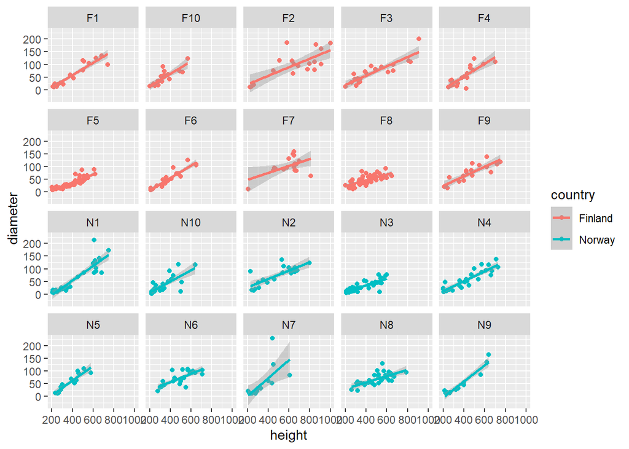

```r
tree_data %>%
  filter(class == 'tree') %>%
  ggplot(aes(height, diameter, color = country)) +
  geom_point() +
  geom_smooth(method = 'lm') +
  facet_wrap(~transect)
```

saplings

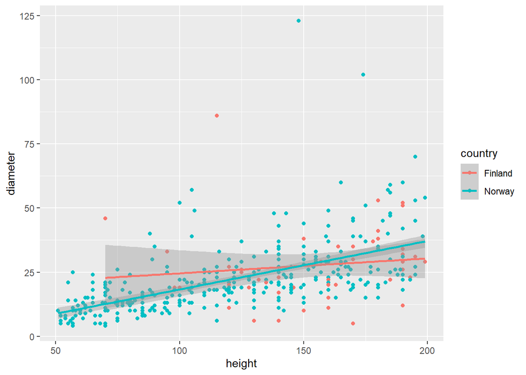

```r
tree_data %>%
  filter(class == 'sapling') %>%
  ggplot(aes(height, diameter, color = country)) +
  geom_point() +
  geom_smooth(method = 'lm')
```

saplings (per transect)

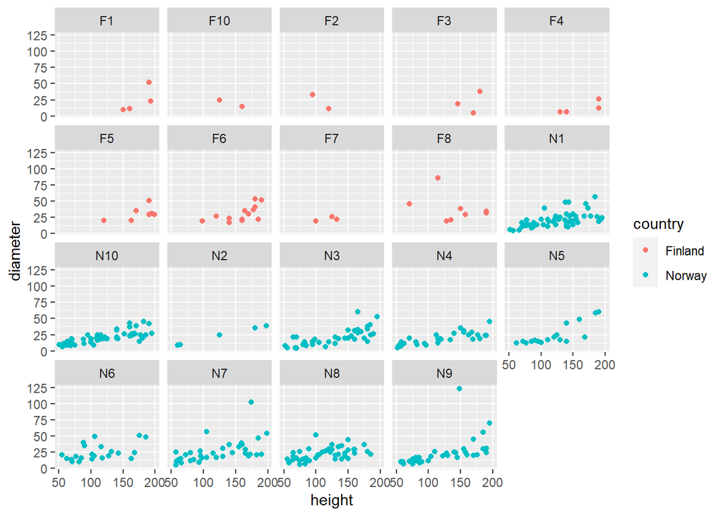

```r
tree_data %>%
  filter(class == 'sapling') %>%
  ggplot(aes(height, diameter, color = country)) +
  geom_point() +
  #geom_smooth(method = 'lm') +
  facet_wrap(~transect)
```

seedlings

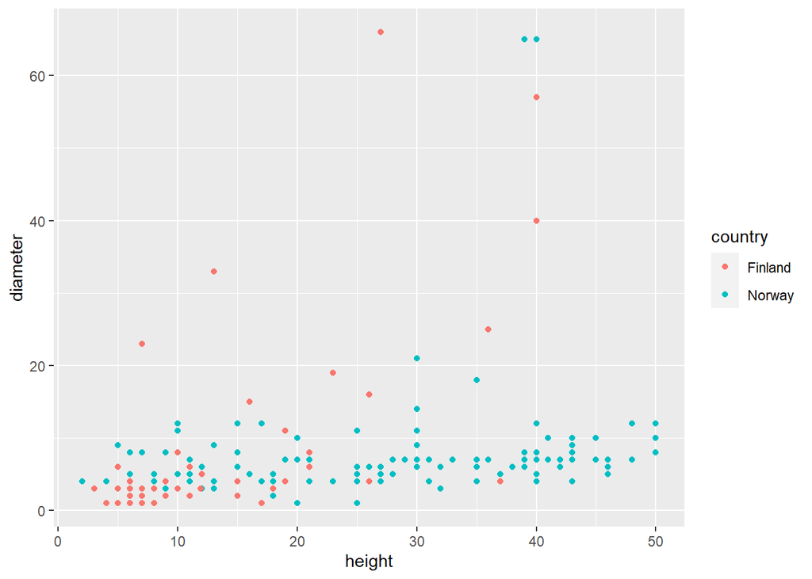

```r
tree_data %>%
  filter(class == 'seedling') %>%
  ggplot(aes(height, diameter, color = country)) +
  geom_point() #+
```

```r
  #geom_smooth(method = 'lm') +
  #facet_wrap(~transect)
```

**growth form vs stem diameter**

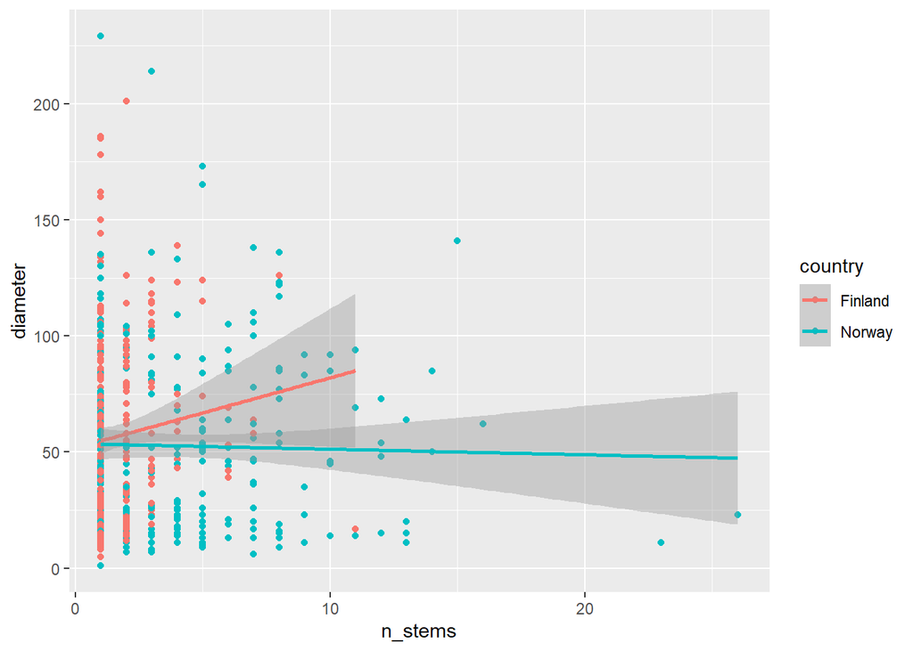

```r
tree_data %>%
  filter(class == 'tree') %>%
  ggplot(aes(n_stems, diameter, color = country)) +
  geom_point() +
  geom_smooth(method = 'lm')
```

**trees along transect**

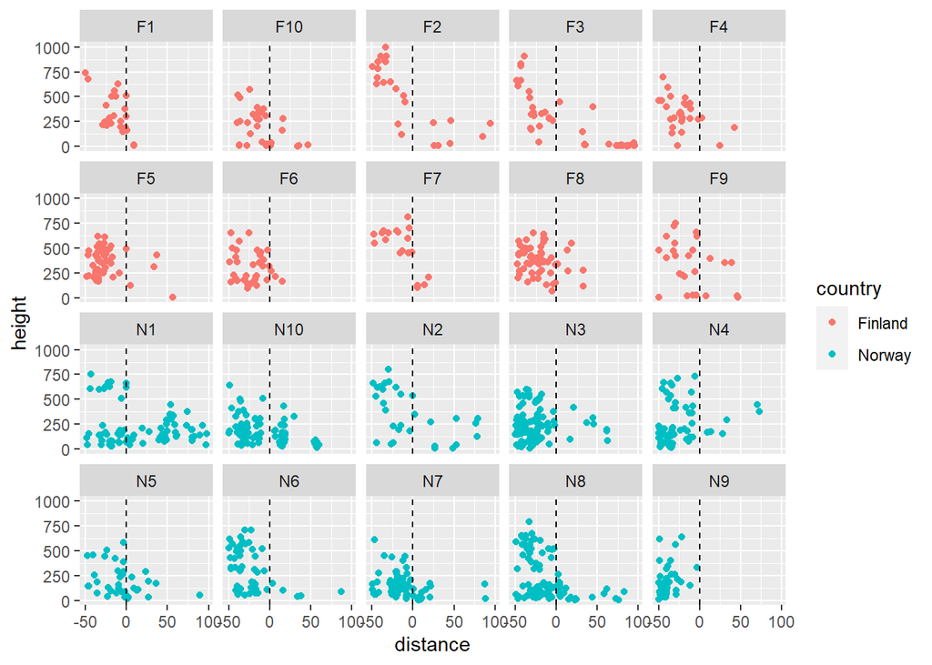

```r
tree_data %>%
  ggplot(aes(distance, height, color = country)) +
  geom_point() +
  geom_vline(aes(xintercept = 0), linetype = 'dashed') +
  facet_wrap(~transect)
```

transect N8 in particular shows a more smooth transition from continuous forest to open tundra

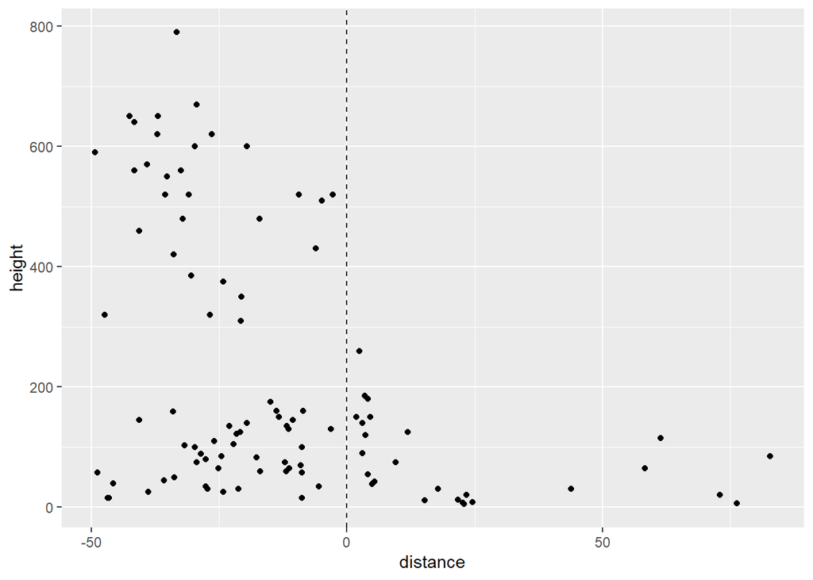

```r
tree_data %>%
  filter(transect == 'N8') %>%
  ggplot(aes(distance, height)) +
  geom_point() +
  geom_vline(aes(xintercept = 0), linetype = 'dashed')
```

**numbers of stems**

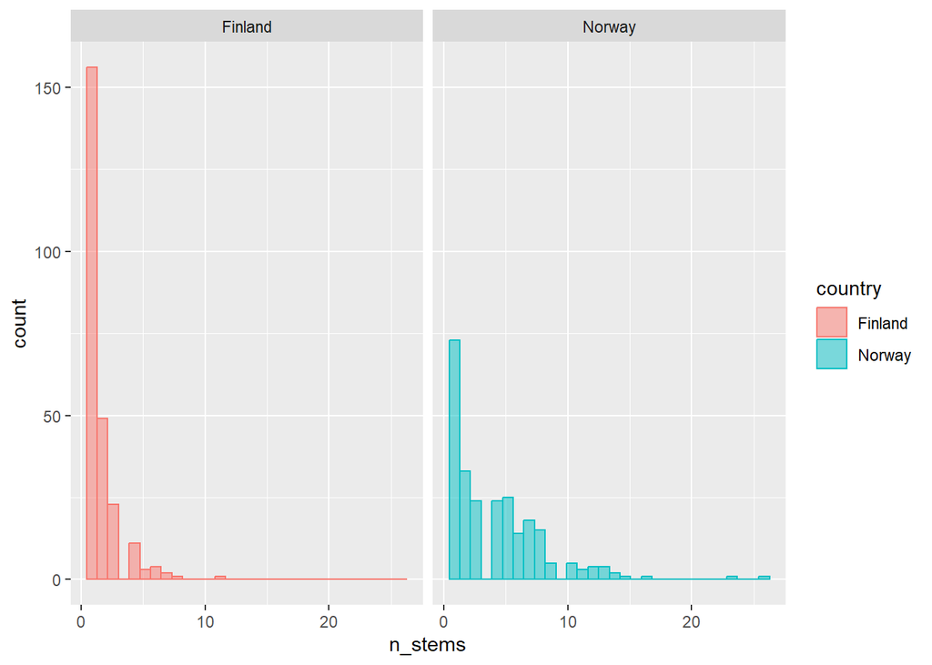

```r
tree_data %>%
  filter(class == 'tree') %>%
  ggplot(aes(n_stems, color = country, fill = country)) +
  geom_histogram(alpha = 0.5,
                position="identity") +
  facet_wrap(~country)
```